# LabourMarketFramework – User Guide

## 4. Output methods and examples

Every example below uses the `lmf` instance from the **First call** section above. The examples are independent: skip directly to the method you care about.

### Output 1: Beveridge curve

#### [12] **`plot_beveridge_curve`**

Plot the Beveridge curve, the job openings rate (`JTSJOR`) against the unemployment rate (`UNRATE`). Points are coloured by year, recession months can be ringed in red.

**Signature:**

```python
plot_beveridge_curve(
    start_date=None,
    end_date=None,
    annotate_recessions=True,
    cmap="plasma",
)
```

**Arguments**

- `start_date`, `end_date : str | None`, default `None`. Date window.
- `annotate_recessions : bool`, default `True`. Ring recession months in red.
- `cmap : str`, default `"plasma"`. Any matplotlib colormap name.

**Returns**

- `matplotlib.figure.Figure`.

**Raises**

- `ValueError` on bad dates or empty window (JOLTS data starts December 2000).

**Default call:**

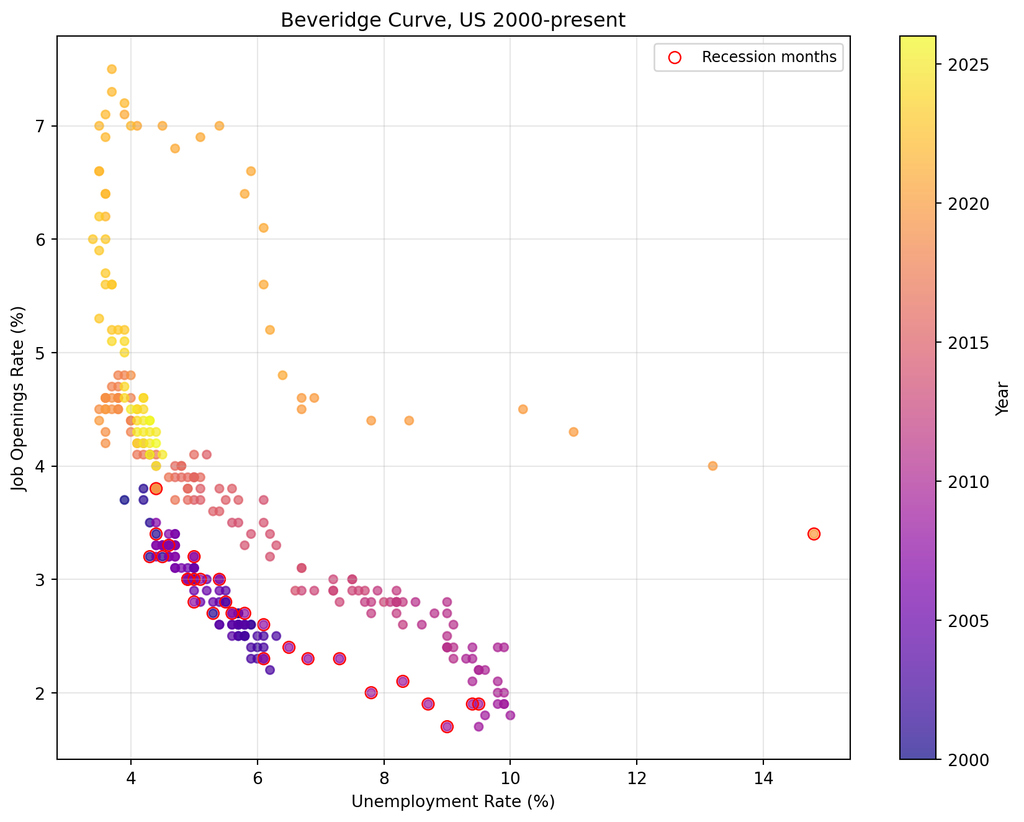

Default: full sample, points coloured by year, recession months ringed in red.

```python
fig = lmf.plot_beveridge_curve()
```

**Variant:**

*(restricted window, no recession rings, different colormap)*

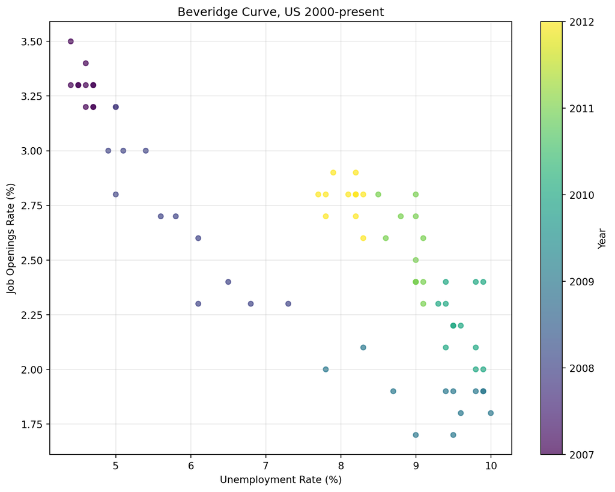

2007-2012 window, no recession rings, viridis colormap.

```python
fig = lmf.plot_beveridge_curve(
    start_date="2007-01-01",
    end_date="2012-12-31",
    annotate_recessions=False,
    cmap="viridis",
)
```

### Output 2: Descriptive statistics

#### [13] **`descriptive_stats`**

Summary table for every series (count, mean, standard deviation, min, max), with an optional correlation matrix.

**Signature:**

```python
descriptive_stats(
    series_ids=None,
    start_date=None,
    end_date=None,
    include_correlations=False,
)
```

**Arguments**

- `series_ids : list[str] | None`, default `None` (every series).
- `start_date`, `end_date : str | None`, default `None`.
- `include_correlations : bool`, default `False`. If `True`, also returns the correlation matrix. The matrix covers only the monthly series and is 8x8; the annual `MASTERS_ENROLLMENT` is dropped to avoid mixing frequencies.

**Returns**

- `pandas.DataFrame` (stats only), or `(stats, corr)` tuple when `include_correlations=True`.

**Raises**

- `ValueError` on unknown `series_ids` or bad dates.

**Default call:**

```python
lmf.descriptive_stats()
```

Default: summary statistics for every series in the database.

|  | count | mean | std | min | max |
| --- | --- | --- | --- | --- | --- |
| JTSHIL | 304.0 | 5189.10 | 681.40 | 3639.0 | 8133.0 |
| JTSJOR | 304.0 | 3.67 | 1.26 | 1.7 | 7.5 |
| JTSQUR | 304.0 | 2.01 | 0.36 | 1.2 | 3.0 |
| LNS12032194 | 315.0 | 5569.16 | 1782.79 | 3144.0 | 10880.0 |
| LNS14027662 | 315.0 | 2.87 | 1.02 | 1.5 | 8.4 |
| MASTERS_ENROLLMENT | 23.0 | 2788406.00 | 306684.73 | 2156896.0 | 3211199.0 |
| PAYEMS | 316.0 | 140653.77 | 9268.02 | 129706.0 | 158736.0 |
| UNRATE | 315.0 | 5.63 | 1.94 | 3.4 | 14.8 |
| USREC | 316.0 | 0.09 | 0.28 | 0.0 | 1.0 |

**Variant:**

*(With the correlation matrix)*

```python
_, corr = lmf.descriptive_stats(include_correlations=True)
corr
```

Correlation matrix of the monthly series (8x8).

|  | JTSHIL | JTSJOR | JTSQUR | LNS12032194 | LNS14027662 | PAYEMS | UNRATE | USREC |
| --- | --- | --- | --- | --- | --- | --- | --- | --- |
| JTSHIL | 1.00 | 0.85 | 0.89 | -0.60 | -0.48 | 0.62 | -0.62 | -0.25 |
| JTSJOR | 0.85 | 1.00 | 0.85 | -0.47 | -0.43 | 0.80 | -0.59 | -0.25 |
| JTSQUR | 0.89 | 0.85 | 1.00 | -0.77 | -0.68 | 0.59 | -0.78 | -0.15 |
| LNS12032194 | -0.60 | -0.47 | -0.77 | 1.00 | 0.87 | -0.42 | 0.90 | 0.08 |
| LNS14027662 | -0.48 | -0.43 | -0.68 | 0.87 | 1.00 | -0.47 | 0.96 | 0.06 |
| PAYEMS | 0.62 | 0.80 | 0.59 | -0.42 | -0.47 | 1.00 | -0.65 | -0.21 |
| UNRATE | -0.62 | -0.59 | -0.78 | 0.90 | 0.96 | -0.65 | 1.00 | 0.12 |
| USREC | -0.25 | -0.25 | -0.15 | 0.08 | 0.06 | -0.21 | 0.12 | 1.00 |

### Output 3: Composite stress index

#### [14] **`compute_stress_index`**

Aggregate labour-market stress index: a z-scored composite of several FRED series. Higher index-values translate to worse conditions.

**Signature:**

```python
compute_stress_index(
    series_ids=None,
    weights=None,
    start_date=None,
    end_date=None,
    freq="MS",
)
```

**Arguments**

- `series_ids : list[str] | None`, default `None` (every series with `category == 'stress_index'`).
- `weights : dict[str, float] | None`, default `None`. Map each series id to a weight. If omitted, the class applies its default signs: `UNRATE`, `LNS12032194`, `LNS14027662` get `+1`; `JTSJOR`, `JTSHIL`, `JTSQUR`, `PAYEMS` get `-1`.
- `start_date`, `end_date : str | None`, default `None`.
- `freq : str`, default `"MS"`. Target frequency for the internal `align_frequencies` call.

**Returns**

- `pandas.Series` named `"stress_index"`.

**Raises**

- `ValueError` if `weights` is `None` and any requested `series_id` lacks a default sign; if the keys of `weights` do not match `series_ids`, if the sum of absolute weights is zero, or if dates are invalid.

**Default call:**

*(the project’s standard index)*

```python
stress = lmf.compute_stress_index()
print(f"Length: {len(stress)} monthly observations")
print(f"Range:  {stress.index.min().date()} to {stress.index.max().date()}")
print(f"Mean:   {stress.mean():.3f}")
print(f"Stdev:  {stress.std():.3f}")
print(stress.tail())
```

```
Length: 304 monthly observations
Range:  2000-12-01 to 2026-03-01
Mean:   0.001
Stdev:  0.859
date
2025-11-01   -0.429961
2025-12-01   -0.543070
2026-01-01   -0.641413
2026-02-01   -0.470923
2026-03-01   -0.771569
Freq: MS, Name: stress_index, dtype: float64
```

**Variant:**

*(Custom basket and explicit weights - two series, equal weighting)*

```python
custom = lmf.compute_stress_index(
    series_ids=["UNRATE", "JTSJOR"],
    weights={"UNRATE": +1.0, "JTSJOR": -1.0},
)
print(custom.tail())
```

```
date
2025-11-01   -0.477450
2025-12-01   -0.463422
2026-01-01   -0.647881
2026-02-01   -0.542817
2026-03-01   -0.528788
Freq: MS, Name: stress_index, dtype: float64
```

### Output 4: Enrollment overlay

#### [15] **`plot_enrollment_overlay`**

Overlay one FRED series and the YoY growth (%) of master’s enrollment on twin y-axes, with NBER recession bands shaded.

**Signature:**

```python
plot_enrollment_overlay(
    series_id="UNRATE",
    start_date=None,
    end_date=None,
)
```

**Arguments**

- `series_id : str`, default `"UNRATE"`. The FRED series on the left axis.
- `start_date`, `end_date : str | None`, default `None`.

**Returns**

- `matplotlib.figure.Figure`.

**Raises**

- `ValueError` if `series_id` is unknown, dates are invalid, or the window contains no data for one of the two series.

**Default call:**

*(UNRATE versus enrollment growth)*

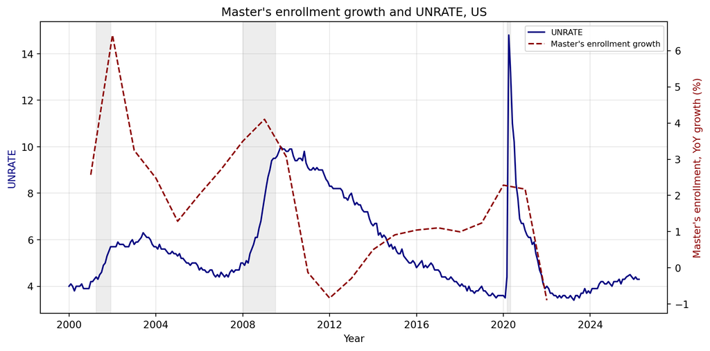

UNRATE on the left axis, master’s enrollment year-over-year growth on the right.

```python
fig = lmf.plot_enrollment_overlay()
```

**Variant:**

*(different FRED series on the left axis)*

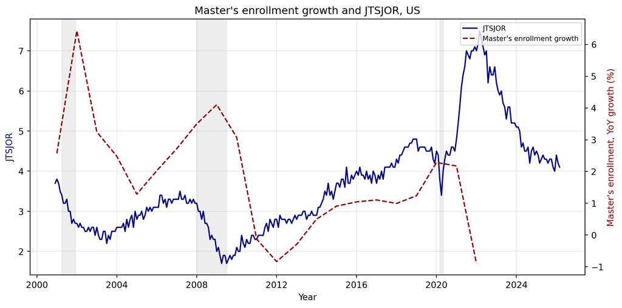

JTSJOR on the left axis, master’s enrollment year-over-year growth on the right.

```python
fig = lmf.plot_enrollment_overlay(series_id="JTSJOR")
```

### Output 5: Stress index versus enrollment

#### [16] **`plot_stress_index_vs_enrollment`**

The broader companion to `plot_enrollment_overlay`. The left axis is the full composite stress index instead of a single FRED series.

**Signature:**

```python
plot_stress_index_vs_enrollment(
    start_date=None,
    end_date=None,
    enrollment_metric="growth",
)
```

**Arguments**

- `matplotlib.figure.Figure`.

**Raises**

- `ValueError` on bad dates, empty window, or unsupported `enrollment_metric`.

**Default call:**

*(growth view of enrollment)*

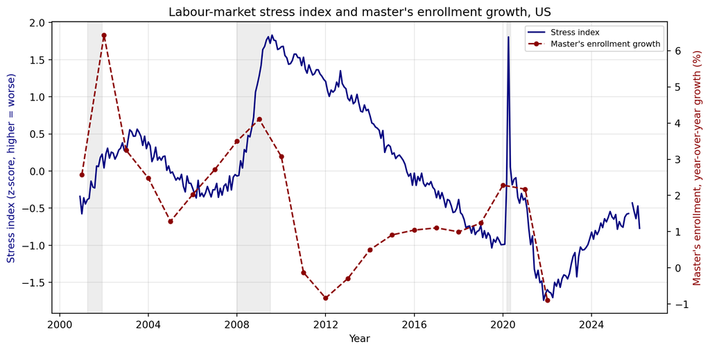

Composite stress index on the left axis, master’s enrollment growth on the right.

```python
fig = lmf.plot_stress_index_vs_enrollment()
```

**Variant:**

*(level view of enrollment)*

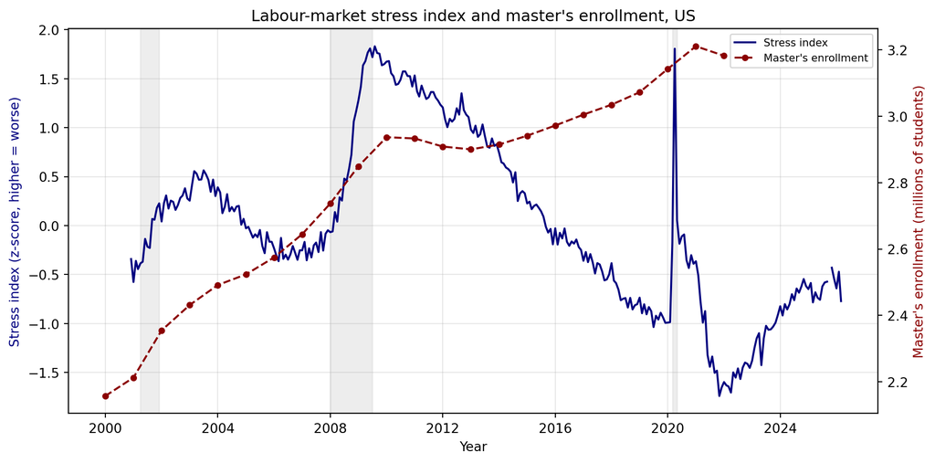

Composite stress index on the left axis, master’s enrollment level (millions of students) on the right.

```python
fig = lmf.plot_stress_index_vs_enrollment(enrollment_metric="level")
```

## 5. Series catalogue

The committed database contains nine series, grouped into five categories. The category is what `available_series(category=...)` and `load_category(category=...)` filter on.

| Category | Series IDs |
| --- | --- |
| `beveridge` | `JTSJOR`, `UNRATE` |
| `stress_index` | `JTSQUR`, `JTSHIL`, `LNS12032194`, `PAYEMS` |
| `recession` | `USREC` |
| `education` | `LNS14027662` |
| `enrollment` | `MASTERS_ENROLLMENT` |

## 6. Errors you might see

Each method validates its inputs before doing any work and raises with a message that explains what went wrong and how to fix it. Four common cases:

- **`FileNotFoundError`** at instantiation: the database is not where `db_path` points. Run `uv run python data/build_fred.py` from the repo root to (re)build it.
- **`ValueError: Series 'X' not in database. Available: [...]`**: you passed a `series_id` that does not exist. The error lists every valid ID.
- **`ValueError: start_date 'X' is not a valid date. Expected format: YYYY-MM-DD.`**: a date argument is malformed. Use the `'YYYY-MM-DD'` format.
- **`ValueError: enrollment_metric must be 'growth' or 'level', got 'X'.`** (or similar for `how` in `align_frequencies`): a string argument is outside the allowed set. The error lists the allowed values.